# Titanic Survival Analysis

```python
import pandas as pd
import numpy as np
import matplotlib.pyplot as plt

titanic_reader = pd.read_csv('titanic-data.csv')
```

Questions for the dataset:

1. How did age and sex affect passenger survival? -Hypothesis: Women and children will have higher than average survival rates and there will be a gradual decline in survival probability as people get older.
2. How did relationships, parent-child and sibling-spouse, affect passenger survival? -Hypothesis: Relationships will play an important role in the lower classes and adults with children will have a competitive advantage for getting on the lifeboats.
3. Does the data show any discrimination against mothers or fathers in their probability of survival? -Hypothesis: Fathers and mothers will be treated less equally as the classes go down. Mothers and fathers will be fairly equally treated at first class, while lower classes will show more favorability for mothers over fathers.

To get started, we should get an overview of the different demographics associated with their respective classes on the Titanic. We will start by clearing any rows that do not have a class entry:

```python
print (titanic_reader.count())
titanic_class = titanic_reader.dropna(subset=['Pclass'], how='all')
print(titanic_class.count())
```

```
PassengerId    891
Survived       891
Pclass         891
Name           891
Sex            891
Age            714
SibSp          891
Parch          891
Ticket         891
Fare           891
Cabin          204
Embarked       889
dtype: int64
PassengerId    891
Survived       891
Pclass         891
Name           891
Sex            891
Age            714
SibSp          891
Parch          891
Ticket         891
Fare           891
Cabin          204
Embarked       889
dtype: int64
```

```python
titanic_third_class = titanic_class[titanic_class["Pclass"] == 3]
print(titanic_third_class.describe())
```

[output not shown]

[output not shown]

Second Class:

```python
titanic_second_class = titanic_class[titanic_class["Pclass"] == 2]
print(titanic_second_class.describe())
```

```
       PassengerId    Survived  Pclass         Age       SibSp       Parch  \
count   184.000000  184.000000   184.0  173.000000  184.000000  184.000000
mean    445.956522    0.472826     2.0   29.877630    0.402174    0.380435
std     250.852161    0.500623     0.0   14.001077    0.601633    0.690963
min      10.000000    0.000000     2.0    0.670000    0.000000    0.000000
25%     234.500000    0.000000     2.0         NaN    0.000000    0.000000
50%     435.500000    0.000000     2.0         NaN    0.000000    0.000000
75%     668.000000    1.000000     2.0         NaN    1.000000    1.000000
max     887.000000    1.000000     2.0   70.000000    3.000000    3.000000

             Fare
count  184.000000
mean    20.662183
std     13.417399
min      0.000000
25%     13.000000
50%     14.250000
75%     26.000000
max     73.500000
```

Third Class:

```python
titanic_third_class = titanic_class[titanic_class["Pclass"] == 3]
print(titanic_third_class.describe())
```

```
       PassengerId    Survived  Pclass         Age       SibSp       Parch  \
count   491.000000  491.000000   491.0  355.000000  491.000000  491.000000
mean    439.154786    0.242363     3.0   25.140620    0.615071    0.393075
std     264.441453    0.428949     0.0   12.495398    1.374883    0.888861
min       1.000000    0.000000     3.0    0.420000    0.000000    0.000000
25%     200.000000    0.000000     3.0         NaN    0.000000    0.000000
50%     432.000000    0.000000     3.0         NaN    0.000000    0.000000
75%     666.500000    0.000000     3.0         NaN    1.000000    0.000000
max     891.000000    1.000000     3.0   74.000000    8.000000    6.000000

             Fare
count  491.000000
mean    13.675550
std     11.778142
min      0.000000
25%      7.750000
50%      8.050000
75%     15.500000
max     69.550000
```

I am curious how age and sex affects the likelihood of survival. I remember a scene in the "Titanic", when the stewards were yelling out "women and children!" for priority on the lifeboats. Let's see how this played out during the real sinking of the Titanic. First i'll analyze how age affected survival:

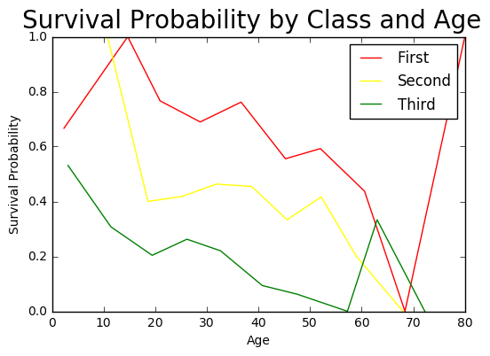

```python
import scipy.stats

## clear out any rows with missing ages
titanic_ages = titanic_reader.dropna(subset=['Age'], how='all')

plt.xlabel("Age")
plt.ylabel("Survival Probability")
plt.suptitle('Survival Probability by Class and Age', fontsize=20)

##plt.plot(age_group['Age'], age_group['Survived'])
titanic_group_first = titanic_ages[titanic_ages['Pclass'] == 1]
titanic_group_second = titanic_ages[titanic_ages['Pclass'] == 2]
titanic_group_third = titanic_ages[titanic_ages['Pclass'] == 3]

def put_in_age_group(df):
    return df.groupby(pd.cut(df['Age'], 10)).mean()

##age_group = titanic_ages.groupby(pd.cut(titanic_ages['Age'], 10)).mean()

ages_first_class = put_in_age_group(titanic_group_first)
ages_second_class = put_in_age_group(titanic_group_second)
ages_third_class = put_in_age_group(titanic_group_third)



plt.plot(ages_first_class['Age'], ages_first_class['Survived'],'red', label = "First")
plt.plot(ages_second_class['Age'], ages_second_class['Survived'],'yellow', label = "Second")
plt.plot(ages_third_class['Age'], ages_third_class['Survived'],'green', label = "Third")
plt.legend()
plt.show()
```

The above line graphs shows a clear trend to see people under the age of 15 to 20 as children. In all three classes we see a trough between the ages of around 15 to 30, where those ages seem particularly vulnerable to being left off the life boat. Possibly because those are the adult non-child bearing years, which lowered their priority. There is an uptick from around mid 20s to 40s, and then it goes downhill from there until at the outlier old ages, where there is a slight uptick in survival. Lets see if there is an actaul uptick with child bearing adults from ages 25 to 40. Lets calculate the mean survival rate for those with children between 25 and 40 and those who dont have children.

```python
parent_child_group = titanic_reader[titanic_reader['Parch'] >1]
parent_child_age = parent_child_group[parent_child_group['Age'] > 25 ]
parental_age_with_kids = parent_child_age[parent_child_age['Age'] <40]
parental_group = parental_age_with_kids.groupby('Age', as_index = False).mean()

print("Survival probability for parents between ages of 25 and 40: "+ "{0:.0f}%".format(parental_group['Survived'].mean() *100))
no_children = titanic_reader[titanic_reader['Parch'] ==0]
no_children_ad = no_children[no_children['Age']> 25]
no_children_adult = no_children_ad[no_children_ad['Age'] <40]
print ("Survival probability for non-child bearing adults between ages of 25 and 40: " +"{0:.0f}%".format(no_children_adult['Survived'].mean() *100))
```

```
Survival probability for parents between ages of 25 and 40: 53%
Survival probability for non-child bearing adults between ages of 25 and 40: 41%
```

There is a benefit for having kids! Let's see if there is any discrimination on the lifeboats against mom or dad...

```python
father_mother = parental_age_with_kids.groupby('Sex', as_index = False).mean()
print ("Father survival probability: "+"{0:.0f}%".format(father_mother.iloc[1]["Survived"] *100))
print ("Mother survival probability: " +"{0:.0f}%".format( father_mother.iloc[0]["Survived"] *100))
```

```
Father survival probability: 17%
Mother survival probability: 73%
```

Ouch... the fathers were really left off the lifeboats. Let's delve deeper into the data to find out how sex and class effect survival.

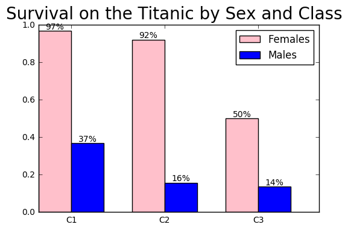

```python
titanic_group_sex_class = titanic_reader.groupby(["Sex", "Pclass"], as_index = False).mean()
titanic_group_female = titanic_group_sex_class[titanic_group_sex_class['Sex'] =="female"]
titanic_group_male = titanic_group_sex_class[titanic_group_sex_class['Sex'] == 'male']
width = 0.35
fig = plt.figure()
ax = fig.add_subplot(111)
rects1 = ax.bar(titanic_group_female['Pclass'], titanic_group_female['Survived'],width, color='pink', label = "Females")
rects2 = ax.bar(titanic_group_male['Pclass']+width, titanic_group_male['Survived'], width, color='blue', label = "Males")
ax.set_xticks(titanic_group_female['Pclass']+width)
ax.set_xticklabels( ('C1', 'C2', 'C3') )


def autolabel(rects):
    # attach some text labels
    for rect in rects:
        height = rect.get_height()
        ax.text(rect.get_x()+rect.get_width()/2., height,"{0:.0f}%".format( height *100),
                ha='center', va='bottom')

autolabel(rects1)
autolabel(rects2)
plt.suptitle('Survival on the Titanic by Sex and Class', fontsize=20)
plt.legend()
plt.show()
```

The data seems to show a strong correlation between Sex and survival. Not even males in first class got close to women's survival rate in third class. Now, lets examine how lateral relations between siblings and spouses or vertical relationships between parents and children played a role in survival.

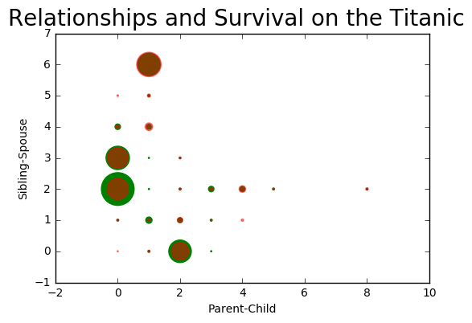

```python
sibling_spouse_group = titanic_reader.groupby(['Parch','SibSp'], as_index = False).mean()
survived_sibling_spouse = np.array(sibling_spouse_group[sibling_spouse_group['Survived'] ==1])
deceased_sibling_spouse = np.array(sibling_spouse_group[sibling_spouse_group['Survived'] ==0])
plt.scatter(sibling_spouse_group['SibSp'], sibling_spouse_group['Parch'],color= "green", alpha =1, s = survived_sibling_spouse)
plt.scatter(sibling_spouse_group['SibSp'], sibling_spouse_group['Parch'],color= "red", alpha = .5, s = deceased_sibling_spouse)

plt.xlabel("Parent-Child")
plt.ylabel("Sibling-Spouse")
plt.suptitle('Relationships and Survival on the Titanic', fontsize=20)
plt.show()
```

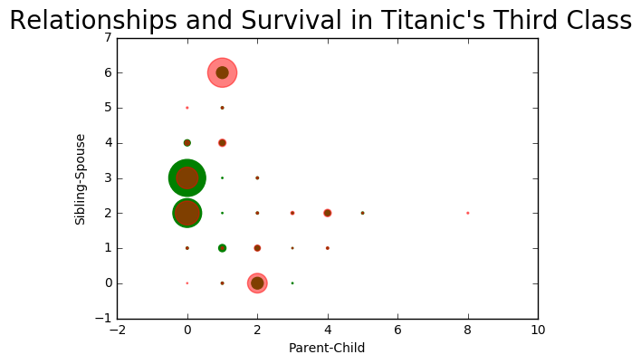

```python
titanic_third = titanic_reader[titanic_reader["Pclass"] == 3]
sibling_spouse_third = titanic_third.groupby(['Parch','SibSp'], as_index = False).mean()

survived_sibling_spouse = np.array(sibling_spouse_third[sibling_spouse_third['Survived'] ==1])
deceased_sibling_spouse = np.array(sibling_spouse_third[sibling_spouse_third['Survived'] ==0])
%matplotlib inline
plt.scatter(sibling_spouse_group['SibSp'], sibling_spouse_group['Parch'],color= "green", alpha = 1,  s = survived_sibling_spouse)
plt.scatter(sibling_spouse_group['SibSp'], sibling_spouse_group['Parch'],color= "red", alpha = .5, s = deceased_sibling_spouse)

plt.xlabel("Parent-Child")
plt.ylabel("Sibling-Spouse")
plt.suptitle('Relationships and Survival in Titanic\'s Third Class', fontsize=20)
plt.show()
```